# Kernel Density Estimation in R

What ArcGIS Pro Hides From You

Kyle J. Redican, PhD

April 2026

## Setup and Data

Load libraries and read in the Gainesville traffic accident data.

```r
library(spatstat)
library(sf)

# Working Directory
setwd("C:/Users/kredican/Desktop/FloridaInterviewMaterials/KernelDensityMapping/Rcode")

# Load shapefiles
boundary <- st_read("GainesvilleBoundary.shp", quiet = TRUE)
accidents <- st_read("Trafficaccidents2025.shp", quiet = TRUE)

# Convert to spatstat point pattern object
win <- as.owin(boundary)
coords <- st_coordinates(accidents)
pp <- ppp(coords[,1], coords[,2], window = win)
```

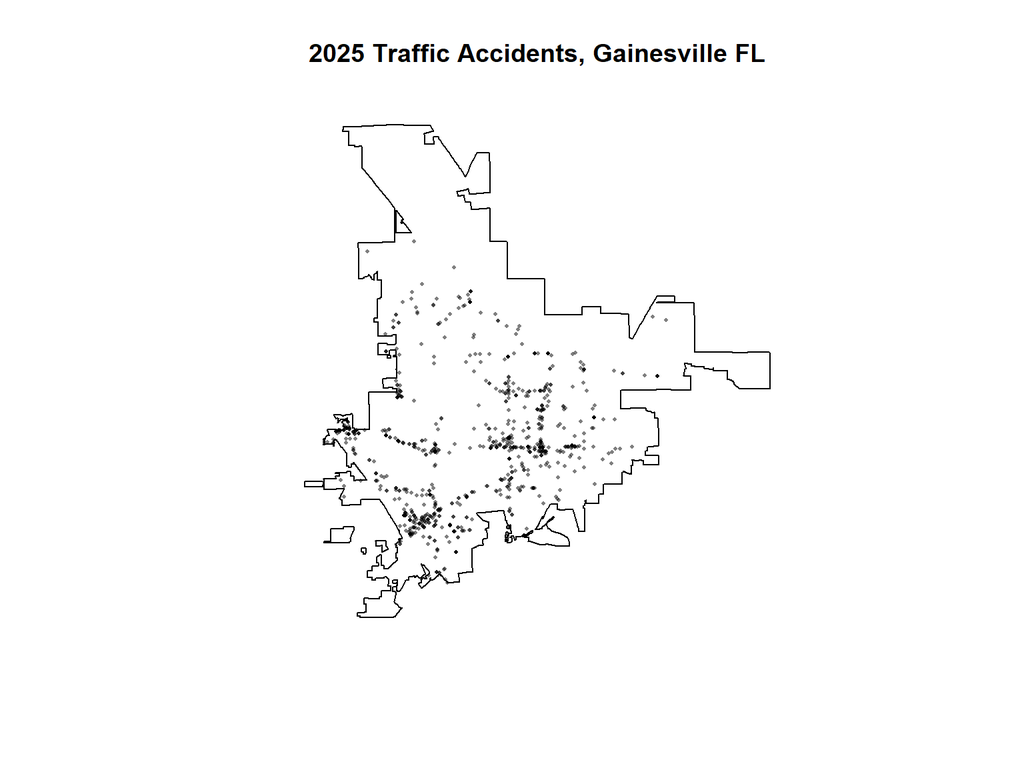

Raw point pattern: 2025 Traffic Accidents in Gainesville, FL

```r
plot(pp, main = "2025 Traffic Accidents, Gainesville FL", pch = 16, cex = 0.4)
```

## KDE With Full Control

In ArcGIS Pro, the Kernel Density tool makes two decisions for you:

- **Kernel function:** Quartic (locked, cannot change)
- **Bandwidth:** Silverman’s rule of thumb (or manual entry)

In R, both are yours to choose.

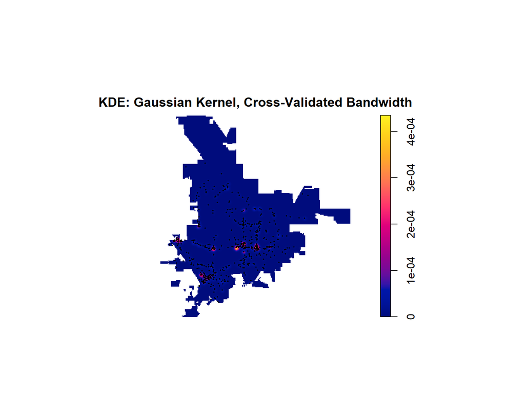

KDE with Gaussian kernel and cross-validated bandwidth

```r
kde_result <- density(pp,
  kernel = "gaussian",
  sigma  = bw.ppl(pp),
  dimyx  = c(256, 256))

plot(kde_result, main = "KDE: Gaussian Kernel, Cross-Validated Bandwidth")
plot(pp, add = TRUE, pch = 16, cex = 0.3, col = "black")
```

## Bandwidth: The Most Important Parameter

Three different methods, three different answers. All are defensible. ArcGIS Pro only gives you one.

```r
bw_scott <- mean(bw.scott(pp))
bw_cv        <- bw.ppl(pp)
bw_diggle    <- bw.diggle(pp)


bw_table <- data.frame(
  Method = c("Scott's Rule (normal reference)",
             "Likelihood Cross-Validation",
             "Diggle's Method"),
  Bandwidth_m = round(c(bw_scott, bw_cv, bw_diggle), 1),
  Notes = c("Fast, assumes unimodal distribution",
            "Data-driven, minimizes prediction error",
            "Minimizes mean squared error")
)

knitr::kable(bw_table, col.names = c("Method", "Bandwidth (m)", "Notes"),
             caption = "Bandwidth Selection: Same Data, Different Answers")
```

Bandwidth Selection: Same Data, Different Answers

| Method | Bandwidth (m) | Notes |
| --- | --- | --- |
| Scott’s Rule (normal reference) | 848.7 | Fast, assumes unimodal distribution |
| Likelihood Cross-Validation | 139.5 | Data-driven, minimizes prediction error |
| Diggle’s Method | 4.9 | Minimizes mean squared error |

### Visual Comparison

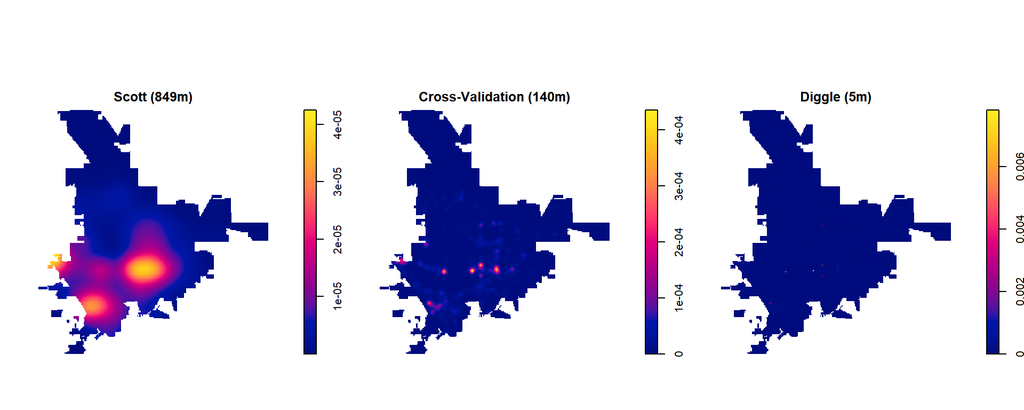

Same kernel (Gaussian), three different bandwidths

```r
par(mfrow = c(1, 3), mar = c(2, 2, 3, 1))

kde_scott <- density(pp, kernel = "gaussian", sigma = bw_scott, dimyx = c(256, 256))
kde_cv   <- density(pp, kernel = "gaussian", sigma = bw_cv, dimyx = c(256, 256))
kde_dig  <- density(pp, kernel = "gaussian", sigma = bw_diggle, dimyx = c(256, 256))

plot(kde_scott, main = paste0("Scott (", round(bw_scott, 0), "m)"))
plot(kde_cv,   main = paste0("Cross-Validation (", round(bw_cv, 0), "m)"))
plot(kde_dig,  main = paste0("Diggle (", round(bw_diggle, 0), "m)"))
```

**Key takeaway:** The bandwidth you choose changes your conclusions. If your results shift dramatically with small bandwidth changes, your data may not support the analysis at that scale.

## Kernel Shape: It Matters Less Than You Think

ArcGIS Pro locks you to the quartic kernel. R lets you compare. Here are four kernel functions applied to the same data with the same bandwidth.

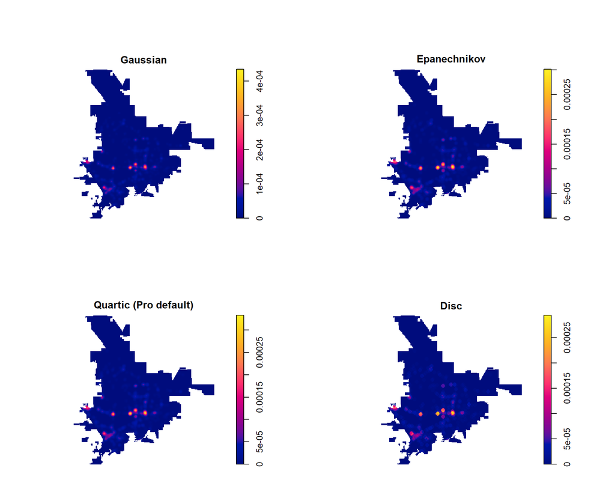

Same bandwidth (cross-validated), four different kernel functions

```r
par(mfrow = c(2, 2), mar = c(2, 2, 3, 1))

kde_gauss <- density(pp, kernel = "gaussian",      sigma = bw_cv, dimyx = c(256, 256))
kde_epan  <- density(pp, kernel = "epanechnikov",   sigma = bw_cv, dimyx = c(256, 256))
kde_quart <- density(pp, kernel = "quartic",        sigma = bw_cv, dimyx = c(256, 256))
kde_disc  <- density(pp, kernel = "disc",           sigma = bw_cv, dimyx = c(256, 256))

plot(kde_gauss, main = "Gaussian")
plot(kde_epan,  main = "Epanechnikov")
plot(kde_quart, main = "Quartic (Pro default)")
plot(kde_disc,  main = "Disc")
```

Notice how similar the outputs are. The kernel shape produces subtle differences. The bandwidth produces dramatic ones. This is why bandwidth selection matters more than kernel choice.

## What Pro Gives You vs. What R Gives You

[output not shown]

## The Bottom Line

Pro is a great tool for applied GIS work. But when you need to **defend your analytical choices**, understand what the tool is doing, or compare methods systematically, you need to move beyond the GUI.

Every decision in this document is visible, reproducible, and yours.

*Built with R Markdown. Source code and data available on [GitHub](https://github.com/redicank/DensityFunctions).*